# R Notebook

```r
library(rpart)
library(rpart.plot)
library(tidyverse)
library(GGally)
library(modelr)
library(yardstick)
library(caret)
library(tidyverse)
titanic_set <- read_csv('data/titanic_decision_tree_data.csv')
shuffle_index <- sample(1:nrow(titanic_set))

# shuffle the data so class order isn't in order - need this for training/testing split later on
titanic_set <- titanic_set[shuffle_index, ]
```

### Question 1

Cleaning up the data is always the first step. Do the following:

- Take only observations which have a survived flag (i.e. that aren’t missing)
- Turn your important variables into factors (sex, survived, pclass, embarkation)
- Create an age_status variable which groups individuals under (and including) 16 years of age into a category called “child” category and those over 16 into a category called “adult”
- Drop the NA
- Drop any variables you don’t need (X1, passenger_id, name, ticket, far, cabin)

```r
head(titanic_set)
```

| ...1 | passenger_id | pclass | name | sex | age | sib_sp | parch | ticket | fare | cabin | embarked | survived |
| --- | --- | --- | --- | --- | --- | --- | --- | --- | --- | --- | --- | --- |
| 1011 | 593 | 3 | Elsbury, Mr. William James | male | 47 | 0 | 0 | A/5 3902 | 7.2500 | NA | S | 0 |
| 451 | 33 | 3 | Glynn, Miss. Mary Agatha | female | NA | 0 | 0 | 335677 | 7.7500 | NA | Q | 1 |
| 597 | 179 | 2 | Hale, Mr. Reginald | male | 30 | 0 | 0 | 250653 | 13.0000 | NA | S | 0 |
| 1298 | 880 | 1 | Potter, Mrs. Thomas Jr (Lily Alexenia Wilson) | female | 56 | 0 | 1 | 11767 | 83.1583 | C50 | C | 1 |
| 937 | 519 | 2 | Angle, Mrs. William A (Florence "Mary" Agnes Hughes) | female | 36 | 1 | 0 | 226875 | 26.0000 | NA | S | 1 |
| 574 | 156 | 1 | Williams, Mr. Charles Duane | male | 51 | 0 | 1 | PC 17597 | 61.3792 | NA | C | 0 |

```r
glimpse(titanic_set)
```

```
Rows: 1,309
Columns: 13
$ ...1         <dbl> 1011, 451, 597, 1298, 937, 574, 994, 811, 1010, 170, 924, 743, 698, 145, 968, 6, 942, 294, 792,…
$ passenger_id <dbl> 593, 33, 179, 880, 519, 156, 576, 393, 592, 1061, 506, 325, 280, 1036, 550, 897, 524, 1185, 374…
$ pclass       <dbl> 3, 3, 2, 1, 2, 1, 3, 3, 1, 3, 1, 3, 3, 1, 2, 3, 1, 1, 1, 2, 3, 3, 1, 3, 3, 2, 3, 1, 3, 3, 3, 3,…
$ name         <chr> "Elsbury, Mr. William James", "Glynn, Miss. Mary Agatha", "Hale, Mr. Reginald", "Potter, Mrs. T…
$ sex          <chr> "male", "female", "male", "female", "female", "male", "male", "male", "female", "female", "male…
$ age          <dbl> 47.0, NA, 30.0, 56.0, 36.0, 51.0, 19.0, 28.0, 52.0, 22.0, 18.0, NA, 35.0, 42.0, 8.0, 14.0, 44.0…
$ sib_sp       <dbl> 0, 0, 0, 0, 1, 0, 0, 2, 1, 0, 1, 8, 1, 0, 1, 0, 0, 1, 0, 1, 0, 0, 0, 1, 0, 0, 1, 0, 1, 1, 0, 0,…
$ parch        <dbl> 0, 0, 0, 1, 0, 1, 0, 0, 0, 0, 0, 2, 1, 0, 1, 0, 1, 1, 0, 0, 0, 0, 0, 0, 0, 0, 0, 0, 9, 0, 0, 0,…
$ ticket       <chr> "A/5 3902", "335677", "250653", "11767", "226875", "PC 17597", "358585", "3101277", "36947", "7…
$ fare         <dbl> 7.2500, 7.7500, 13.0000, 83.1583, 26.0000, 61.3792, 14.5000, 7.9250, 78.2667, 8.9625, 108.9000,…
$ cabin        <chr> NA, NA, NA, "C50", NA, NA, NA, NA, "D20", NA, "C65", NA, NA, NA, NA, NA, "B18", "A34", NA, NA, …
$ embarked     <chr> "S", "Q", "S", "C", "S", "C", "S", "S", "C", "S", "C", "S", "S", "S", "S", "S", "C", "S", "C", …
$ survived     <dbl> 0, 1, 0, 1, 1, 0, 0, 0, 1, NA, 0, 0, 1, NA, 1, NA, 1, NA, 0, NA, 0, 1, NA, 1, NA, 0, 0, NA, NA,…
```

```r
summary(titanic_set)
```

```
      ...1       passenger_id      pclass          name               sex                 age            sib_sp
 Min.   :   1   Min.   :   1   Min.   :1.000   Length:1309        Length:1309        Min.   : 0.17   Min.   :0.0000
 1st Qu.: 328   1st Qu.: 328   1st Qu.:2.000   Class :character   Class :character   1st Qu.:21.00   1st Qu.:0.0000
 Median : 655   Median : 655   Median :3.000   Mode  :character   Mode  :character   Median :28.00   Median :0.0000
 Mean   : 655   Mean   : 655   Mean   :2.295                                         Mean   :29.88   Mean   :0.4989
 3rd Qu.: 982   3rd Qu.: 982   3rd Qu.:3.000                                         3rd Qu.:39.00   3rd Qu.:1.0000
 Max.   :1309   Max.   :1309   Max.   :3.000                                         Max.   :80.00   Max.   :8.0000
                                                                                     NA's   :263
     parch          ticket               fare            cabin             embarked            survived
 Min.   :0.000   Length:1309        Min.   :  0.000   Length:1309        Length:1309        Min.   :0.0000
 1st Qu.:0.000   Class :character   1st Qu.:  7.896   Class :character   Class :character   1st Qu.:0.0000
 Median :0.000   Mode  :character   Median : 14.454   Mode  :character   Mode  :character   Median :0.0000
 Mean   :0.385                      Mean   : 33.295                                         Mean   :0.3838
 3rd Qu.:0.000                      3rd Qu.: 31.275                                         3rd Qu.:1.0000
 Max.   :9.000                      Max.   :512.329                                         Max.   :1.0000
                                    NA's   :1                                               NA's   :418
```

```r
titanic_clean <- titanic_set %>%
  janitor::clean_names() %>%
  filter(is.na(survived) == FALSE) %>%
  mutate(sex = as.factor(sex),
         survived = factor(survived, levels = c(0, 1), labels = c("Dead", "Survived")),
         class = factor(pclass, levels = c(1, 2, 3), labels = c("Lower", "Middle", "Upper")),
         port_embarkation = factor(embarked, levels = c("S", "C", "Q"), labels = c("Southampton", "Cherbourg", "Queenstown")),
         age_status = as.factor(if_else(age <= 16, "Child", "Adult"))) %>%
  rename(par_ch = parch) %>%
  select(-c(x1, passenger_id, pclass, name, ticket, fare, cabin, embarked)) %>%
  na.omit()

titanic_clean
```

| sex | age | sib_sp | par_ch | survived | class | port_embarkation | age_status |
| --- | --- | --- | --- | --- | --- | --- | --- |
| male | 47.00 | 0 | 0 | Dead | Upper | Southampton | Adult |
| male | 30.00 | 0 | 0 | Dead | Middle | Southampton | Adult |
| female | 56.00 | 0 | 1 | Survived | Lower | Cherbourg | Adult |
| female | 36.00 | 1 | 0 | Survived | Middle | Southampton | Adult |
| male | 51.00 | 0 | 1 | Dead | Lower | Cherbourg | Adult |
| male | 19.00 | 0 | 0 | Dead | Upper | Southampton | Adult |
| male | 28.00 | 2 | 0 | Dead | Upper | Southampton | Adult |
| female | 52.00 | 1 | 0 | Survived | Lower | Cherbourg | Adult |
| male | 18.00 | 1 | 0 | Dead | Lower | Cherbourg | Adult |
| female | 35.00 | 1 | 1 | Survived | Upper | Southampton | Adult |

[output cut: 702 more lines]

```r
NA
```

### Question 2

Have a look at your data and create some plots to ensure you know what you’re working with before you begin. Write a summary of what you have found in your plots. Which variables do you think might be useful to predict whether or not people are going to die? Knowing this before you start is the best way to have a sanity check that your model is doing a good job.

```r
skimr::skim(titanic_clean)
```

```
── Data Summary ────────────────────────
                           Values
Name                       titanic_clean
Number of rows             712
Number of columns          8
_______________________
Column type frequency:
  factor                   5
  numeric                  3
________________________
Group variables            None
```

|  | skim_variable | n_missing | complete_rate | ordered | n_unique | top_counts |
| --- | --- | --- | --- | --- | --- | --- |
| 1 | sex | 0 | 1 | FALSE | 2 | mal: 453, fem: 259 |
| 2 | survived | 0 | 1 | FALSE | 2 | Dea: 424, Sur: 288 |
| 3 | class | 0 | 1 | FALSE | 3 | Upp: 355, Low: 184, Mid: 173 |
| 4 | port_embarkation | 0 | 1 | FALSE | 3 | Sou: 554, Che: 130, Que: 28 |
| 5 | age_status | 0 | 1 | FALSE | 2 | Adu: 612, Chi: 100 |

|  | skim_variable | n_missing | complete_rate | mean | sd | p0 | p25 | p50 | p75 | p100 | hist |
| --- | --- | --- | --- | --- | --- | --- | --- | --- | --- | --- | --- |
| 1 | age | 0 | 1 | 29.6420927 | 14.4929329 | 0.42 | 20 | 28 | 38 | 80 | ▂▇▅▂▁ |
| 2 | sib_sp | 0 | 1 | 0.5140449 | 0.9306921 | 0.00 | 0 | 0 | 1 | 5 | ▇▁▁▁▁ |
| 3 | par_ch | 0 | 1 | 0.4325843 | 0.8541814 | 0.00 | 0 | 0 | 1 | 6 | ▇▁▁▁▁ |

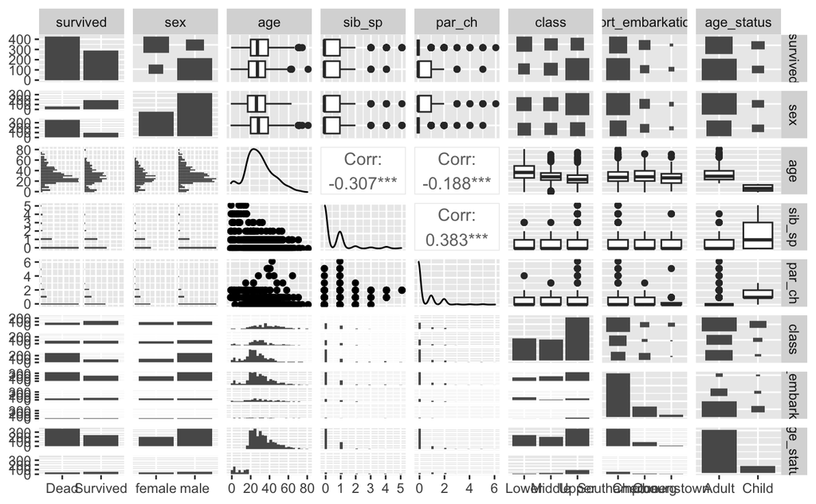

```r
plot <- ggpairs(titanic_clean %>%
          select(survived, everything()))

plot2 <- getPlot(plot, i = 1, j = 5)
print(plot)
```

Based on the above plot, I expect the discriminant variables to be, in descending order of impact:  
- sex  
- class  
- age_status

### Question 3

Now you can start to build your model. Create your testing and training set using an appropriate split. Check you have balanced sets. Write down why you chose the split you did and produce output tables to show whether or not it is balanced.  
[Extra - if you want to force balanced testing and training sets, have a look at the stratified() function in package splitstackshape (you can specify multiple variables to stratify on by passing a vector of variable names to the group argument, and get back testing and training sets with argument bothSets = TRUE)]

```r
# install.packages("splitstackshape")
library(splitstackshape)

titanic_samples <- stratified(titanic_clean, group = c("sex", "class", "age_status"), size = 0.3, bothSets = TRUE)

titanic_samples$SAMP1 %>%
 janitor::tabyl(survived)
```

```
 survived   n  percent
     Dead 128 0.600939
 Survived  85 0.399061
```

```r
titanic_samples$SAMP2 %>%
  janitor::tabyl(survived)
```

```
 survived   n   percent
     Dead 296 0.5931864
 Survived 203 0.4068136
```

I’ve chosen to pass the 3 more significant variables to the group argument, with size 30% / 70% as the data set is not very large.  
Upon checking, the percentage of survived passenger is very similar in both train and test sample.

### Question 4

Create your decision tree to try and predict survival probability using an appropriate method, and create a decision tree plot.

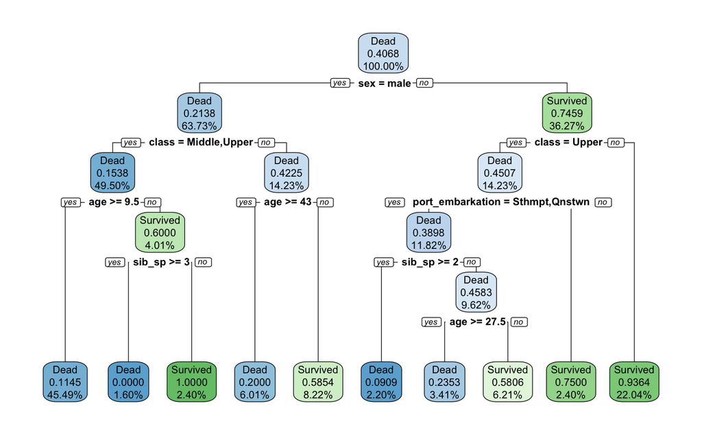

```r
titanic_fit <- rpart(
  formula = survived ~ .,
  data = titanic_samples$SAMP2,
  method = 'class'
)

rpart.plot(titanic_fit,
           yesno = 2,
           fallen.leaves = TRUE,
           faclen = 6,
           digits = 4)
```

### Question 5

Write down what this tells you, in detail. What variables are important? What does each node tell you? Who has the highest chance of surviving? Who has the lowest? Provide as much detail as you can.

### Question 6

Test and add your predictions to your data. Create a confusion matrix. Write down in detail what this tells you for this specific dataset.

```r
# add the predictions from train (SAMP2) to test (SAMP1)
titanic_test_pred <- titanic_samples$SAMP1 %>%
  add_predictions(titanic_fit, type = 'class')

titanic_test_pred
```

| sex | age | sib_sp | par_ch | survived | class | port_embarkation | age_status | pred |
| --- | --- | --- | --- | --- | --- | --- | --- | --- |
| male | 24.00 | 0 | 0 | Dead | Upper | Southampton | Adult | Dead |
| male | 74.00 | 0 | 0 | Dead | Upper | Southampton | Adult | Dead |
| male | 21.00 | 0 | 0 | Dead | Upper | Southampton | Adult | Dead |
| male | 33.00 | 0 | 0 | Dead | Upper | Southampton | Adult | Dead |
| male | 37.00 | 2 | 0 | Dead | Upper | Southampton | Adult | Dead |
| male | 22.00 | 0 | 0 | Dead | Upper | Southampton | Adult | Dead |
| male | 18.00 | 0 | 0 | Dead | Upper | Southampton | Adult | Dead |
| male | 20.00 | 0 | 0 | Dead | Upper | Southampton | Adult | Dead |
| male | 33.00 | 0 | 0 | Dead | Upper | Southampton | Adult | Dead |
| male | 21.00 | 0 | 0 | Dead | Upper | Southampton | Adult | Dead |

[output cut: 203 more lines]

```r
conf_mat <- titanic_test_pred %>%
              conf_mat(truth = survived, estimate = pred)

conf_mat
```

```
          Truth
Prediction Dead Survived
  Dead      111       22
  Survived   17       63
```

The main diagonal represents correctly-predicted values, with the top right values showing false positives and the bottom left being false negatives. The main diagonal values are reasonably the high, therefore our decision tree is fairly accurate.

```r
accuracy <- titanic_test_pred %>%
 accuracy(truth = survived, estimate = pred)

accuracy
```

| .metric | .estimator | .estimate |
| --- | --- | --- |
| accuracy | binary | 0.8169014 |

```r
confusionMatrix(titanic_test_pred$pred, titanic_test_pred$survived)
```

```
Confusion Matrix and Statistics

          Reference
Prediction Dead Survived
  Dead      111       22
  Survived   17       63

               Accuracy : 0.8169
                 95% CI : (0.7583, 0.8664)
    No Information Rate : 0.6009
    P-Value [Acc > NIR] : 1.041e-11

                  Kappa : 0.6144

 Mcnemar's Test P-Value : 0.5218

            Sensitivity : 0.8672
            Specificity : 0.7412
         Pos Pred Value : 0.8346
         Neg Pred Value : 0.7875
             Prevalence : 0.6009
         Detection Rate : 0.5211
   Detection Prevalence : 0.6244
      Balanced Accuracy : 0.8042

       'Positive' Class : Dead
```